*Created by Petteri Nevavuori <petteri.nevavuori@gmail.com>*

**CHIO & FREEMAN: MACHINE LEARNING & SECURITY (2018)**  
*Otsikot kirjan mukaan, muutoin suomeksi.*

# Network Traffic Analysis

Yleisin tapa, jolla hyökkääjä saa jalansijan kohdejärjestelmästä, on verkkoyhteyksiä hyödyntämällä. Verkkoturvallisuus on laaja ylätason käsite niille toimille, joilla pyritään estämään ja ehkäisemää verkon yli tapahtuvaa haitallista vaikuttamista. Tässä luvussa keskitytään verkkoliikenteen luokitteluun alkamalla oman verkon puolustuksen mallista ja jatkaen siitä koneoppimis- ja tekoälytutkimuksesta hyötyneisiin verkkoturvallisuuden sovelluksiin. Luvussa käydään läpi esimerkki korrelaatioiden löytämisestä ja piirteiden tunnistuksesta verkkoliikenteestä.

Luku rajoittuu pakettitason liikenteen tarkasteluun, mikä sisältää tietoa verkkoliikenteen lähteistä, kohteista, protokollista ja ainakin jotain sisällöstä. [OSI-mallista](https://fi.wikipedia.org/wiki/OSI-malli) käsittelyn kohteina ovat tasot 3-5, eli verkko-, kuljetus- ja istuntokerrokset. Kuten jo aiemmista luvuista on tullut ilmi, haitallinen verkkoliikenne on osa joko varsinaisen hyökkäyksen alkua (tunnustelu) tai sitten loppusiivousta (datan välitys).

## Theory of Network Defense

Verkkojen puolustaminen on monimutkaista laajakirjoisten hyökkäystapojen ja -alustojen vuoksi. Yksittäisiä hyökkäyksiä joudutaan torjumaan useilla verkon osa-alueista eikä verkon osien luotettavuus ole näissä tilanteissa taattu.

### Access Control and Authentication

Verkon kanssa tapahtuva vuorovaikutus alkaa aina pääsyn hallinnalla, joka on auktorisoinnin ja käyttäjien kontrolloinnin keino. Palomuurit ovat esimerkki tällaisesta hallinnasta, jolla pyritään rajaamaan ensimmäinen haitallisten vuorovaikutusten massa verkon ulkopuolelle eväämällä pääsy sinne. Pääsyn hallinnan käytänteillä (*policy*) saadaan verkkoon pääsevät toimijat rajoitettua pääsyn puolesta edelleen vain tiettyihin, sallittuihin osiin (esim. julkinen web-palvelu). Aktiivisella autentikoinnilla (*active authentication*) rajoitetaan edelleen pääsyä vaatimalla käyttäjiltä tunnistautumista esimerkiki käyttäjätunnuksin tai SSH-avaimin. Monivaiheiselle tunnistautumisella (*multi-factor authentication, MFA*) voidaan myös nostaa joidenkin perustasoisten hyökkäysten etenemisen kynnystä.

### Intrusion Detection

Tunkeutumisen havaitsemista käsiteltiin aiemmin jo luvussa kolme. Tunkeutumisen havaintojärjestelmät käsittävät usein tunnistusta laajemman kokonaisuuden murtojen tunnistamiseksi. Näiden ohella tunkeutumisen estojärjestelmiä voidaan käyttää aktiiviseen havaitun haitallisen toiminnan estämiseen.

### Detecting In-Network Attackers

Mikäli voidaan olettaa, että hyökkääjällä on mahdollisuus ohittaa pääsyn hallinta ja päästä käsiksi verkkoon toimien sen sisällä, on keskityttävä haitallisen toiminnan havaitsemiseen verkon sisällä. Hyvin suunnitellut järjestelmät lähtevät siitä, että näin tulee tapahtumaan tai on jo tapahtunut. Tämä edellyttää järjestelmän valvojilta verkon osien instrumentointia ja aktiivista valvontaa poikkeavien muutosten varalta.

Pelkän verkon rajan vahvistaminen ei riitä, sillä verkkoon päästään sisään useimmiten, tavalla tai toisella. Tästä syystä verkko ja siihen liitettävät järjestelmät on suunniteltava niin, että murron tapahtuessa kokonaisuus säilyisi kuitenkin mahdollisimman pitkään mahdollisimman eheänä (vrt. valtamerilaivojen pato-ovet). Erityisen tärkeää on erotella liiketoiminnalle merkittävät korkean riskin osat julkisisesti saavutettavista ja sallia vain tarkasti määritellyt ja valvotut API-kutsut näiden välillä. Tämä mikrosegmentointi vaatii jatkuvaa huomiota, sillä verkon rakenteen muuttuessa on segmentointiakin päivitettävä.

### Data-Centric Security

Järjestelmän tilan vaarantuessa datan varkauden todennäköisyys kasvaa merkittävästi. Tällöin datakeskeisyys on järjestelmän kyberturvan suunnittelussa tärkeää, jolloin jopa tietokannankin tullessa murretuksi ei datasta itsestään ole juuri hyötyä hyökkääjälle. Dataa, kuten käyttäjätunnuksia, onkin tavattu suojata hash-algoritmeilla, mutta kaikkeen dataan tämä ei sovi, ei etenkään aktiivisesti käytössä olevaan. Ratkaisuja on kuitenkin jo esitetty, kuten homomorfinen salaus, jossa analyysiä voidaan suorittaa suoraan salatulla datalla ilman tarvetta salauksen purkuun.

### Honeypots

Hunajapurkit ovat käytännössä valemaaleja, houkuttimia, joiden tarkoituksena on vaikuttaa ulkopuoliselle toimijalla mielenkiintoiselta kohteelta. Murron tapahduttua hyökkääjästä pyritään keräämään mahdollisimman paljon tietoa. Hunajapurkki voi muodostua yhdestä palvelimesta aina kokonaiseen verkkoon saakka. Hyvin rakennettuna ja oikeita toimintoja matkivina hunajapurkit voivat hämätä hyökkääjää hyvinkin pitkälle. Niitä voidaan käyttää myös datan keruuseen hyökkääjien havaitsemiseksi, sillä kaikki hunajapurkin data on lähtökohtaisesti vahingollista vaikuttamista.

## Machine Learning and Network Security

Ilmiötä selittävien piirteiden louhinta datasta (*pattern mining*) on koneoppimisen vahvuuksia. Vaikka yksittäistä paketeista ei juuri piirteitä ole louhittavissa, verkon liikenne muodostuu monitahoisista ja -kerroksisista viestinnän ketjuista. Tällaista liikenteen raakadataa kutsukaan pakettisieppaukseksi (*packet capture*). Sieppauksista voidaan eristää yksittäiset monista paketeista muodostuvat istunnot, joiden rakenne ja sisältö määrittyy vahvasti eri protokollien mukaisesti. Pelkästään tästä datasta voidaan jo pyrkiä tunnistamaan mm. bottiverkoilla (*botnet*) toteutettuja palvelunestohyökkäyksiä (*denial of service, DoS*).

### From Captures to Features

Verkkoliikenteen keruun pääkeino on olemassaolevan liikenteen sieppaaminen. Pakettien analysointityökaluilla liikenteestä saadaan muodostettua mm. lokitiedostoja, joita käyttämällä on mahdollista analysoida ja mallintaa verkon toimintaa halutulla laajuudella haittaliikenteen lisäksi myös esimerkiksi sen suorituskyvyn mittaamiseksi. Oikein verkon eri osiin sijoiteltuina pakettien analysointityökaluja voidaan käyttää yksityiskohtaisten datajoukkojen tuottamiseen.

Liikenteen koostaminen laajoja keskustelusekvenssejä sisältävistä istunnoista yksittäisiksi sekvenssejä kuvaaviksi piirteiksi auttaa laajojen datamäärien käsittelyssä. Istuntokohtaisesti näitä tietoja ovat:

- Ajallinen kesto
- Pakettien kokonaismäärä
- Käytetty protokolla
- Istunnossa siirretyt tavut suuntaan ja toiseen
- Istunnon kohteen palvelu, jota tavoiteltiin

Tärkeintä on joka tapauksessa määritellä kerättävät piirteet sen mukaisesti, mitä liikenteestä tahdotaan selvittää. Tämä on riippuvaista kohdejärjestelmästä.

### Threats in the Network

Tässä vaiheessa kirjassa käydään läpi verkkouhkia, luokitellen ne karkeasti passiivisiin ja aktiivisiin uhkiin. Kuten luvun alussakin mainittiin, keskitytään uhkakeskustelussa OSI-mallin kerroksiin 3-5, eikä täten esimerkiksi fyysisiä uhkatekijöitä käsitellä.

#### Passive attacks

Passiiviset hyökkäykset nimensä mukaisesti eivät kommunikoi verkon solmujen (*node*) kanssa eivät pyri esimerkiksi muokkamaan niissä olevaa dataa. Passiivisia hyökkäyksiä käytetäänkin usein tiedonkeruuseen, jolla pyritään saamaan tärkeää lisätietoa varsinaisten aktiivisempien hyökkäysten toteuttamiseen. Porttien skannaus (*port scanning*) on esimerkki passiivisesta hyökkäyksestä, jossa avoimia portteja selvittämällä pyritään pääsemään selvyyteen kohdejärjestelmästä ja siinä mahdollisesti olevista paremmin hyväksikäytettävistä palveluista. Esimerkiksi avoimena portti 27017 kertoo, että kohteessa on käynnissä MongoDB-tietokantainstanssi.

#### Active attacks

Aktiiviset murrot jaotellaan kirjassa seuraavasti:

- **Murtautumiset** (*breaches*): Verkkomurrot ovat hyökkäyksistä tuotteliaimpia, ja murrolla voidaan viitata sekä aukon muodostamiseen verkon rajalla tai olemassaolevan aukon hyödyntämiseen. Aukko on usein kohdejärjestelmän verkon ja ulkoisen maailman rajapinnassa olevissa osissa: mm. reitittimissä, palomuureissa ja kytkimissä. Aukko muodostetaan keräämällä kohteesta ensin riittävästi tietoa, jotta kohdejärjestelmän osien heikkouksia hyväksikäyttämällä saavutetaan korotetut vaikkapa käyttäjäoikeudet (*privilege elevation*) ja kohdejärjestelmässä päästään täten suorittamaan haluttuja toimenpiteitä. Murrot voivat olla sekä ulkoa että sisältä tehtyjä. Sisältä tehtynä kyseessä on kokonaisuutena paljon laajempi ja monimutkaisempi havaittava asia, jota on lähestyttävä ennemmin koko ympäristön turvallisuussuunnitelun näkökulmasta.
- **Väärentämiset** (*spoofing*): Väärennetyn datan lähetystä, *spoofausta*, käytetään haitallisen jalansijan saavuttamisen mekanismina luotettujen viestintäyhteyksien sisällä. Näillä menetelmillä voidaan esimerkiksi välimuisti myrkyttää siten, että palvelu saadaan keskustelemaan alun perin suunnitellusta poikkeavaan, vihamieliseen kohteeseen. Esimerkiksi DNS-väärennöksessä tavoitteena on muokata kohdejärjestelmän välimuistiin tallennetun verkko-osoitteiden tietoja ylläpitävän DNS-taulun tietoja siten, että tuttu verkko-osoite saadaan osoittamaan aivan johonkin muuhun sijaintiin.
- **Pivottaus** (*pivoting*): Suomenkielisen sanan puutteessa *pivottauksella* tarkoitetaan sitä, kun sisään päästyään hyökkääjä pyrkii liikkumaan järjestelmästä tai palvelimesta toiseen järjestelmän verkon sisäpuolella. Tällöin pyrkimyksenä on hyväksikäyttää heikommin suunniteltuja palvelujen välisiä suojia ja edetä esimerkiksi julkisen web-palvelun palvelimesta aina kriittistä dataa sisältäviin palvelimiin ja järjestelmän osiin.
- **Palvelunestohyökkäykset**: Näiden hyökkäysten tavoitteena on kohdejärjestelmän yleinen lamauttaminen ja käytön estäminen tai ainakin hankaloittaminen. Yksi tapa palvelunestohyökkäyksen toteuttamiseen on hyväksikäyttää TCP-kättelymekanismia, jossa jokaisen uuden yhteydenoton yhteydessä palvelimelle lähetetään SYN-paketti. Palvelin lähettää tähän vastauksensa, minkä jälkeen se jää kuuntelemaan uutta vastausta yhteyttä ottaneesta lähteestä. Tätä hyväksikäytetään siten, että muodostetaan jatkuvalla syötöllä uusia yhteydenottopyyntöjä ilman, että palvelimen odottamaa vastausta kuitenkaan lähetetään. Näin kohdejärjestelmän vapaat resurssit vähenevät vähenemistään sen ylläpitäessä puoliavoimia yhteyksia enenevissä määrin ja lopulta se vähintään hidastuu, ellei jopa kokonaan kaadu. Tässä yhteydessä käytetään usein bottiverkkoja, joihin keskitytään hetkeksi seuraavassa osiossa.

### Botnets and You

Puolet verkon liikenteestä on bottien tuottamaa, mutta kaikki niiden toiminta ei missään tapauksessa ole vahingollista (esim. hakukoneen indeksointibotit). Joka tapauksessa haitallisen bottiverkkojen luoman liikenteen osuus maailmanlaajuisesta liikenteestä on useita, ellei jopa joitain kymmeniä prosentteja. Mikäli bottiverkot sijaitsevat maantieteellisesti keskitetysti on niiltä suojautuminen suoraviivaista IP:n suodatusta. Toisaalta, suuret bottiverkot osaavat laajeta valtaamalla suojaamattomia kotiverkoissakin sijaitsevia koneita. Tällöin haitallisen bottiverkkoliikenteen suodatus osoittautuukin jo kertaluokkaa haastavammaksi tehtäväksi.

#### The importance of understanding botnets

Bottiverkkojen luoma riski yritysverkoille ja organisaatioille ylipäätään on todellinen. Verkon osana toimivat mutta bottiverkon näkökulmasta uinuvat zombi-koneet ovat verkon aktivoituessa merkittävä uhka. Niillä voidaan suorittaa ulkopuolelta tulevien hyökkäysten lisäksi myös sisältä ulos suuntautuvia tehtäviä. Koneoppimisen ja tilastollisten menetelmien avulla on mahdollista kuitenkin edes jossain määrin tunnistaa mahdollista bottiverkkoliikennettä. Tällöin esimerkiksi bottiverkkojen toimintaa mallintamalla voidaan pyrkiä oppimaan sellaisia piirteitä, joita hyödyntämällä olisi mahdollista erotella haitallinen liikenne ympäristössä muutoin normaalista liikenteestä. Esimerkiksi klusterointia on hyödynnetty verkkoliikenteeseen uinuvista zombi-koneista niitä hallitseviin järjestelmiin tapahtuvan liikenteen tunnistamiseksi.

#### How do botnets work?

Bottiverkot ovat nimensä mukaisesti läpikotaisin hajautettuja järjestelmiä. Ne on suunniteltu hyvin kestäviksi monenkirjavia sammutus- ja tuhoamisyrityksiä vastaan. Kun jokin kone pyritään liittämään osaksi laajempaa verkkoa, ensimmäisiä siihen tehtäviä toimenpiteitä on komentojärjestelmältä käskyjä odottavan palvelun asentaminen ja käynnistäminen. Bottiverkoilla on neljä pääpiirteistä arkkitehtuuria:

- **Keskitetty tähtimalli**: Yhden komentojärjestelmän ja siihen kytkettyjen koneiden malli on perinteisimpiä bottiverkkojen malleja. Malli on kuitenkin hauras, sillä komentojärjestelmän kaatuessa koko verkko on käyttökelvoton. Koska uinuvilla koneilla on oltava kyky "soittaa kotiin", on niiden oltava jotenkin kykeneviä muodostamaan kyselyjä oikeisiin osoitteisiin. Komentojärjestelmän sijainnin suojelemiseksi IP-osoitteiden sijasta verkon zombi-koneisiin on kehitetty domainien generointialgoritmeja, joilla pyrittiin kiertämään helposti estettävän yhden kiinteän komentojärjestelmään osoittavan domainin käyttöä.
- **Hajatetun johdon malli** (*multileader networks*): Tämän bottiverkon erona tähtimalliin on, että yhden komentojärjestelmän sijasta verkko koostuu useammasta toisiinsa kytketyistä komentojärjestelmistä, joista jokaisella on omat zombinsa hallittavanaan. Hajauttamalla verkkoa maantieteellisesti saadaan sekä suorituskyvyn että toiminnan suojaamisen näkökulmista etua.
- **Hierarkinen malli**: Monen erillisen komentojärjestelmän sijasta tässä mallissa zombi-koneet voivat toimia sekä viestin välittäjinä että bottiverkon osina. Komentoketjun kasvaessa komentojen lähteenä toimiva järjestelmä on entistä paremmin suojassa löytymistä vastaan. Verkon topologian vuoksi reaaliaikaiset toiminnot voivat kuitenkin olla hankalia, sillä käskyjen propagoinnissa on keskitettyä mallia enemmän viivettä.
- **Satunnaistettu hajautettu malli** (*randomized P2P networks*): Tämä malli poistaa keskitetyn komentojärjestelmän kokonaan ja hallinnointi voi tapahtua minkä tahansa verkkoon kytketyn koneen välityksellä. Tämä malli on erityisen tehokas vastustamaan tuhoamista, sillä yhden koneen poistaminen ei juuri muuhun verkkoon vaikuta. Mallin haitta on hierarkista mallia vielä korostuneempi viestin välittämisen viive. Samoin täyttä vakuutta siitä, että viesti menee edes perille, ei ole. Komentojen autentikoinnissa käytetäänkin kryptografisia menetelmiä, jotka ovat paremmin tunnettuina käytössä mm. kryptovaluutoissa.

## Building a Predictive Model to Classify Network Attacks

### Exploring the Data

Aloitetaan ensin datan lataamisella ja tutkinnalla. Ensin alustetaan datasettien polut ja sarakkeet. Datan sarakkeiden nimet on kopioitu kirjasta.

```python
import os
from collections import defaultdict

NSL_KDD_DIR = os.path.join(os.getcwd(),'datasets','NSL-KDD-Dataset')

features = defaultdict(list)
nsl_kdd_headers = []
with open(os.path.join(NSL_KDD_DIR,'features.txt')) as f:
    for line in f.readlines():
        feature, feature_type = line.strip().replace(':','').replace('.','').split()
        features[feature_type].append(feature)
        nsl_kdd_headers.append(feature)

print(f'All data headers: {nsl_kdd_headers}\n')
```

[output not shown]

Ladataan seuraavaksi tiedot hyökkäystyyppien (`attack_type`) kategorioista.

```python
categories = defaultdict(list)
categories['benign'].append('normal')

with open(os.path.join(NSL_KDD_DIR,'training_attack_types.txt'),'r') as f:
    for line in f.readlines():
        attack, cat = line.strip().split(' ')
        categories[cat].append(attack)

attack_mapping = dict((v,k) for k in categories for v in categories[k])
attack_mapping
```

```
{'normal': 'benign',
 'apache2': 'dos',
 'back': 'dos',
 'mailbomb': 'dos',
 'processtable': 'dos',
 'snmpgetattack': 'dos',
 'teardrop': 'dos',
 'smurf': 'dos',
 'land': 'dos',
 'neptune': 'dos',
 'pod': 'dos',
 'udpstorm': 'dos',
 'ps': 'u2r',
 'buffer_overflow': 'u2r',
 'perl': 'u2r',
 'rootkit': 'u2r',
 'loadmodule': 'u2r',
 'xterm': 'u2r',
 'sqlattack': 'u2r',
 'httptunnel': 'u2r',
 'ftp_write': 'r2l',
 'guess_passwd': 'r2l',
 'snmpguess': 'r2l',
 'imap': 'r2l',
 'spy': 'r2l',
 'warezclient': 'r2l',
 'warezmaster': 'r2l',
 'multihop': 'r2l',
 'phf': 'r2l',
 'named': 'r2l',
 'sendmail': 'r2l',
 'xlock': 'r2l',
 'xsnoop': 'r2l',
 'worm': 'probe',
 'nmap': 'probe',
 'ipsweep': 'probe',
 'portsweep': 'probe',
 'satan': 'probe',
 'mscan': 'probe',
 'saint': 'probe'}
```

Seuraavaksi ladataan itse datajoukot siten, että käyttöön otetaan kaikki sarakkeet viimeistä lukuunottamatta. Samoin datajoukkoon lisätään tieto sen hyökkäystyyppien laajemmista kategorioista.

```python
import pandas as pd
train = pd.read_csv(os.path.join(NSL_KDD_DIR,'KDDTrain+.txt'),names=nsl_kdd_headers).iloc[:,:-1]
test = pd.read_csv(os.path.join(NSL_KDD_DIR,'KDDTest+.txt'),names=nsl_kdd_headers).iloc[:,:-1]

train['attack_category'] = train['attack_type'].map(lambda x: attack_mapping[x])
test['attack_category'] = test['attack_type'].map(lambda x: attack_mapping[x])
```

Visualisoidaanpa hieman datajoukon sisältöä.

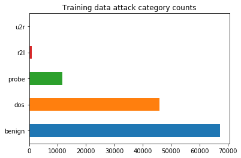

```python
import matplotlib.pyplot as plt
%matplotlib inline
_=train['attack_category'].value_counts().plot(kind='barh',title='Training data attack category counts')
```

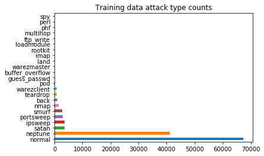

```python
_=train['attack_type'].value_counts().plot(kind='barh',title='Training data attack type counts')
```

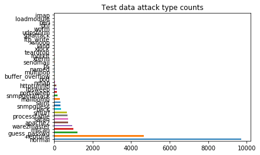

```python
_=test['attack_type'].value_counts().plot(kind='barh',title='Test data attack type counts')
```

Kuten kuvaajista voi huomata, on testidatajoukossa enemmän hyökkäystyyppejä, kuin koulutusjoukossa. Datajoukko suunniteltiin näin, jotta koulutusjoukosta pyrittäisiin oppimaan yleistettäviä (*generalizable*) piirteitä ylisovittumisen (*overfit*) sijasta. Vaikka yökkäystyyppien jakauma datajoukoissa on hyvin epätasainen, tavoitteena onkin oppia hyökkäyskategorioille ominaisia piirteitä. Tapoja epätasaisuuden käsittelyyn löytyy, mutta niitä käsitellään tuonnempana.

### Data Preparation

Seuraavaksi datajoukkoja muokataan, jotta ne saadaan paremmin mallinnusmenetelmiin syötettäviksi.

```python
x_train = train.drop(['attack_type','attack_category'],axis=1)
y_train = train['attack_category']
print(f'Train shapes:\n\tx={x_train.shape}, y={y_train.shape}')

x_test = test.drop(['attack_type','attack_category'],axis=1)
y_test = test['attack_category']
print(f'Test shapes:\n\tx={x_test.shape}, y={y_test.shape}')
```

```
Train shapes:
	x=(125973, 41), y=(125973,)
Test shapes:
	x=(22544, 41), y=(22544,)
```

Osa datajoukon piirteistä on kategorisia. Koska kategoristen piirteiden arvot eivät ole numeerisesti vertailtavissa, on kategoristen piirteiden arvot hajotettava omiksi binääriarvoisiksi sarakkeikseen. Tätä kutsutaan *one-hot*-enkoodaukseksi. Erotellaan ensin numeeriset arvot muista.

```python
print(f"Continuous features: {features['continuous']}\n")
print(f"Symbolic features: {features['symbolic']}")
```

[output not shown]

Symbolisissa arvoissa on sekä kategorisia `(protocol_type, service, flag)` että binäärisiä (`logged_in, ...`) piirteitä. Näistä ensimmäiset vaativat lisätyöstöä. Koska malli koulutetaan tietynmuotoisella datajoukolla, on myös testijoukon oltava samankaltainen. Siksi molemmille joukoille tehdään samat toimenpiteet siten, että joukot yhdistetään samanakaltaisuuden takaamiseksi ja erotetaan käsittelyn jälkeen takaisin.

```python
x_combined = pd.concat([x_train,x_test])
print(f'Shape prior one-hoting:\n\tx_combined={x_combined.shape}')
x_combined = pd.get_dummies(x_combined,columns=['protocol_type','service','flag'],drop_first=True)
print(f'Shape after one-hoting:\n\tx_combined={x_combined.shape}')
x_train,x_test = x_combined.iloc[:len(x_train),:],x_combined.iloc[len(x_train):,:]
print(f'Shapes of datasets:\n\tx_train={x_train.shape}, x_test={x_test.shape}')
```

```
Shape prior one-hoting:
	x_combined=(148517, 41)
Shape after one-hoting:
	x_combined=(148517, 119)
Shapes of datasets:
	x_train=(125973, 119), x_test=(22544, 119)
```

Kuten arvoista voi huomata, on sarakkeiden määrä kasvanut merkittävästi. Otetaanpa seuraavaksi pikainen sarakkeiden tilastollinen tarkastelu arvojen skaalojen ymmärtämiseksi. Mikäli skaalat poikkeavat merkittävästi, on datajoukko vähintään skaalattava piirrekohtaisesti.

```python
print(f'Feature mean-of-means for x_train: {x_train.describe().loc["mean",:].mean():.2f} +-{x_train.describe().loc["mean",:].std():.2f}')
print(f'Feature mean-of-means for x_test: {x_test.describe().loc["mean",:].mean():.2f} +-{x_test.describe().loc["mean",:].std():.2f}')
```

```
Feature mean-of-means for x_train: 555.04 +-4538.93
Feature mean-of-means for x_test: 110.27 +-969.70
```

Eroa on merkittävästi. Siispä seuraavaksi skaalataan kaikki numeeriset arvot. Ne löytyvät aiemmin alustetusta `features`-muuttujasta `continuous`-avaimen alta. Koska datan lukuvaiheessa piirre `success_pred` jätettiin pois, jätetään se tässäkin kohtaa pois.

```python
from sklearn.preprocessing import StandardScaler

x_train,x_test = x_train.astype('float64'),x_test.astype('float64')

scaler_x = StandardScaler().fit(x_train[features['continuous'][:-1]])

x_train[features['continuous'][:-1]] = scaler_x.transform(x_train[features['continuous'][:-1]])
x_test[features['continuous'][:-1]] = scaler_x.transform(x_test[features['continuous'][:-1]])

print('Scaled input datasets:')
print(f'\tx_train={x_train.shape}')
print(f'\tx_test={x_test.shape}')
```

```
Scaled input datasets:
	x_train=(125973, 119)
	x_test=(22544, 119)
```

### Classification

Tässä vaiheessa datan esikäsittely on valmis ja on aika alkaa tekemään valintoja koneoppimismenetelmien suhteen. Datassa on valmiina luokkatiedot viidelle eri luokalle (hyökkäyskategoriat). Menetelmiä, jotka tukevat moniluokkaista luokittelua, ovat mm. puumallit (*decision trees*), lähimpien naapurien (*nearest neighbors*) ja naiivi Bayesilainen (*Naive Bayes*) luokittelija. Myös menetelmiä, jotka tukevat vain joko-tai-luokittelua, voidaan käyttää moniluokkaiseen luokitteluun tietyin lisätoimenpitein. Näitä lisätoimia ovat esimerkiksi binääriluokittimen (tukivektorikone) sovittaminen jokaiseen piirteeseen piirre-vastaan-muut -tyyppisesti, joka tunnetaan paremmin binäärirelevanssin menetelmänä (*binary relevance method*). Tämän keinon käyttö auttaa mallin selitysvoiman säilyttämisessä, sillä jokaiselle piirteelle on oma luokittimensa.

Oikean menetelmän valinta monista eri vaihtoehdoista palaa usein koneoppimisongelmien iteratiiviseen luonteeseen ja siinä kehittyvään intuitioon. Kokeilemalla mahdollisimman montaa menetelmää saa parhaan kuvan siitä, mikä niistä soveltuu parhaiten kyseessä olevaan ongelmaan. Yleisellä tasolla seuraavat asiat määrittävät jokseenkin valittavaan algoritmiin: *datajoukon koko, luokittelu vai regressio, oikeiden vastausten löytyminen ja määrä, käytettävissä oleva aika koulutukseen ja ennustamiseen*.

### Supervised Learning

Ensin keskitytään mallinnukseen lähtökohdasta, jossa käytettävissä on näytekohtaiset oikeat tiedot. Käyttämässämme NSL-KDD datajoukossa koulutusjoukossa löytyy n. 126000 näytettä, joista jokaisen kohdalla löytyy tieto sen kategoriasta. Yleisellä tasolla tarkkuuden lisäksi mallinnuksen tavoitteita ovat myös koulutuksen ja tuotantokäytön tehokkuus. Siksi, mikäli vain mahdollista, on hyvä aloittaa robusteista ja tehokkaasti käytettävistä malleista, joista voidaan edetä sitten haluttaessa haastavammin koulutettaviin mutta tarkempiin malleihin.

```python
from sklearn.tree import DecisionTreeClassifier

classifier = DecisionTreeClassifier(random_state=0)
classifier.fit(x_train,y_train)
```

```
DecisionTreeClassifier(class_weight=None, criterion='gini', max_depth=None,
            max_features=None, max_leaf_nodes=None,
            min_impurity_decrease=0.0, min_impurity_split=None,
            min_samples_leaf=1, min_samples_split=2,
            min_weight_fraction_leaf=0.0, presort=False, random_state=0,
            splitter='best')
```

Sovituksen jälkeen on hyvä tarkastella mallin hyvyyttä. Se tehdään testidatajoukolla.

```python
from sklearn.metrics import confusion_matrix, zero_one_loss

y_pred = classifier.predict(x_test)
error = zero_one_loss(y_test,y_pred)
results = confusion_matrix(y_test, y_pred)

print(f'Accuracy of the classifier: {1-error:.2%}')
print(f'Confusion matrix of classes:')
pd.DataFrame(results,
             index=[f'true_{v}' for v in classifier.classes_],
             columns=[f'pred_{v}' for v in classifier.classes_])
```

```
Accuracy of the classifier: 75.45%
Confusion matrix of classes:
```

|  | pred_benign | pred_dos | pred_probe | pred_r2l | pred_u2r |
| --- | --- | --- | --- | --- | --- |
| true_benign | 9363 | 57 | 289 | 1 | 1 |
| true_dos | 1537 | 5999 | 100 | 0 | 0 |
| true_probe | 708 | 215 | 1500 | 0 | 0 |
| true_r2l | 2413 | 1 | 16 | 135 | 9 |
| true_u2r | 179 | 0 | 4 | 5 | 12 |

Sekaannusmatriisi (*confusion matrix*) on hyvä työkalu luokittelutuloksen arviontiin. Se kertoo, miten malli ylipäätään onnistui luokitteluissaan ja minkä muuttujan kanssa se onnistui kuinka hyvin. Esimerkiksi oikean vastauksen ollessa `benign` ennusti malli oikein noin 9350 havaintoa ja väärin vajaat 350 havaintoa. Tätä ajatusta jatkaen onkin hyvä tässä kohdin selvittää, että mitkä olivat luokkakohtaiset virheet.

```python
print('Accuracies for classes:')
for i, row in enumerate(results):
    wrong_sum = 0
    for j, value in enumerate(row):
        if i == j:
            continue
        wrong_sum += value
    print(f'  {classifier.classes_[i]}: {1-(wrong_sum/row.sum()):.2%}')
```

```
Accuracies for classes:
  benign: 96.42%
  dos: 78.56%
  probe: 61.91%
  r2l: 5.24%
  u2r: 6.00%
```

Visualisoidaanpa myös testijoukon luokkajako kokonaiskuvan muodostamisen helpottamiseksi.

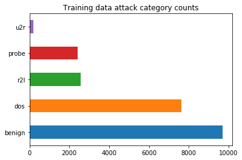

```python
_=test['attack_category'].value_counts().plot(kind='barh',title='Training data attack category counts')
```

Näyttää siltä, että `u2r`-kategoriaan huonon sovittumisen takana on kyseisen kategorian havaintojen vähyys. Normaali liikenne (`benign`) tunnistettiin lähes täysin, ja melko hyvä tarkkuus saavutettiin myös `dos`- ja `probe`-kategorioiden kanssa. Kategorioista `r2l` oli yllättävästi kaikkein huonoiten tunnistettu, sillä suurin osa kyseisistä havainnoista luokiteltiin normaaliks liikenteeksi.

Tarkastellaanpa vielä kategorioiden osuuksia suhteessa mallin ennustamiin osuuksiin.

|  | true | true_ratio | pred | pred_ratio | ratio_diff |
| --- | --- | --- | --- | --- | --- |
| 0 | 9711 | 0.430758 | 14200 | 0.629879 | 0.199122 |
| 1 | 7636 | 0.338715 | 6272 | 0.278211 | -0.060504 |
| 2 | 2574 | 0.114177 | 1909 | 0.084679 | -0.029498 |
| 3 | 2423 | 0.107479 | 141 | 0.006254 | -0.101224 |
| 4 | 200 | 0.008872 | 22 | 0.000976 | -0.007896 |

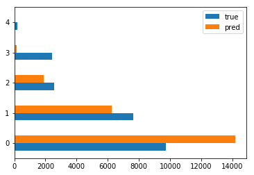

```python
ratios = pd.DataFrame(list(test['attack_category'].value_counts()),columns=['true'])
ratios['true_ratio'] = ratios.true/ratios.true.sum()
ratios['pred'] = results.sum(axis=0)
ratios['pred_ratio'] = ratios.pred/ratios.pred.sum()
ratios['ratio_diff'] = ratios.pred_ratio-ratios.true_ratio
ratios[['true','pred']].plot(kind='barh')
ratios
```

Näyttää siltä, että malli on oppinut ennustamaan pääsääntöisesti luokkaa `benign`. Koska se on eniten edustettu luokka, ennustamalla sitä lähtökohtaisesti useammin takaa pienemmän virheen satunnaisen luokittelun sijasta.

Jotta voidaan varmistua siitä, ettei vain mallin valinta ollut huono, koitetaan kouluttaa myös toinen malli, joka poikkeaa edellisestä puumallista.

```python
from sklearn.neighbors import KNeighborsClassifier

classifier = KNeighborsClassifier(n_neighbors=1,n_jobs=1)
classifier.fit(x_train,y_train)
y_pred = classifier.predict(x_test)
error = zero_one_loss(y_test,y_pred)
results = confusion_matrix(y_test, y_pred)

print(f'Accuracy of the classifier: {1-error:.2%}')
print(f'Confusion matrix of classes:')
pd.DataFrame(results,
             index=[f'true_{v}' for v in classifier.classes_],
             columns=[f'pred_{v}' for v in classifier.classes_])
```

```
Accuracy of the classifier: 75.90%
Confusion matrix of classes:
```

|  | pred_benign | pred_dos | pred_probe | pred_r2l | pred_u2r |
| --- | --- | --- | --- | --- | --- |
| true_benign | 9455 | 57 | 193 | 2 | 4 |
| true_dos | 1675 | 5894 | 67 | 0 | 0 |
| true_probe | 670 | 156 | 1597 | 0 | 0 |
| true_r2l | 2344 | 2 | 37 | 151 | 40 |
| true_u2r | 177 | 0 | 4 | 6 | 13 |

|  | true | true_ratio | pred | pred_ratio | ratio_diff |
| --- | --- | --- | --- | --- | --- |
| 0 | 9711 | 0.430758 | 14321 | 0.635247 | 0.204489 |
| 1 | 7636 | 0.338715 | 6109 | 0.270981 | -0.067734 |
| 2 | 2574 | 0.114177 | 1898 | 0.084191 | -0.029986 |
| 3 | 2423 | 0.107479 | 159 | 0.007053 | -0.100426 |
| 4 | 200 | 0.008872 | 57 | 0.002528 | -0.006343 |

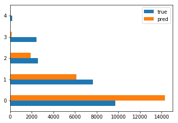

```python
ratios = pd.DataFrame(list(test['attack_category'].value_counts()),columns=['true'])
ratios['true_ratio'] = ratios.true/ratios.true.sum()
ratios['pred'] = results.sum(axis=0)
ratios['pred_ratio'] = ratios.pred/ratios.pred.sum()
ratios['ratio_diff'] = ratios.pred_ratio-ratios.true_ratio
ratios[['true','pred']].plot(kind='barh')
ratios
```

Tulokset ovat samankaltaiset, elleivät jopa lähes identtiset. Kyse on siis luokkien epätasaisesta jakautumisesta.

#### Class imbalance

Epätasaisesti jakautuneiden luokkien kanssa toimiminen on lähestulkoon oma taiteenlajinsa. Pääsääntöisesti on olemassa kaksi lähestymistapaa:

- **Alinäytteistys** (*undersampling*): Menetelmällä pyritään saamaan enemmän edustettujen luokkien lukumäärät samalle tasolle pienempien luokkien kanssa. Vaikka satunnaisesti valittuna alinäytteistys toimiikin, olisi hyvä ennemmin jättää esimerkiksi samankaltaisuuksia toistavat näytteet pois. Tämän kanssa on kuitenkin oltava varovainen, sillä menetelmä muuttaa luonnollisesti datan jakaumaa. Liika alinäytteistys voi myös rampauttaa koneoppimismenetelmän kyvyn tunnistaa todellisesti datassa usein esiintyvää luokkaa.
- **Ylinäytteistys** (*oversampling*): Alinäytteistyksen vastakohtana ylinäytteistyksessä pienemmistä luokista muodostetaan synteettisesti suurempia monistamalla niiden näytteitä. Samalla tavoin kuin alinäytteistyksessä, ylinäytteistyksessä on varottava "likaamasta" vähemmän edustettuja luokkia huolimattomalla näytteistyksellä.

Näitä menetelmiä voi käyttää yhdessä ja erikseen ja yleistä onkin, että ensin ylinäytteistetään ja sitten alinäytteistetään.

Seuraavaksi pyritään soveltamaan näitä menetelmiä käyttämäämme dataan. Aloitetaan selvittämällä datan kategoriset jakaumat.

```python
y_train.value_counts()
```

```
benign    67343
dos       45927
probe     11656
r2l         995
u2r          52
Name: attack_category, dtype: int64
```

Seuraavaksi jatketaan ylinäytteistyksellä käyttämällä SMOTE-menetelmää. Suomeksi menetelmän nimi tarkoittaa synteettistä vähemmistön ylinäytteistystekniikkaa (*synthetic minority oversampling technique*). Perusasetuksillaan menetelmä näytteistää kutakin havaintoa kaikista suurimman luokan määrää vastaavasti.

```python
from imblearn.over_sampling import SMOTE
sampler = SMOTE(random_state=0)
x_train_oversampled, y_train_oversampled = sampler.fit_sample(x_train,y_train)
```

```python
pd.Series(y_train_oversampled).value_counts()
```

```
r2l       67343
probe     67343
u2r       67343
benign    67343
dos       67343
dtype: int64
```

Tämä menetelmä ei liene paras, sillä vain noin 50 havainnon `u2r`-luokkaa on ylinäytteistetty lähes 130000%:sti. Kirjassa päädytäänkin ennemmin käyttämään `RandomUnderSampling`-luokkaa. Sille on syötettävä ennakkotieto haluttavista näytemääristä. Kirjassa päädytään ottamaan keskimääräinen kategoriakohtainen näytemäärä. Toisin sanoen ylinäytteistetyistä luokista muodostetaan vielä alinäytteistetyt luokat.

```python
from imblearn.under_sampling import RandomUnderSampler
mean_class_size = int(y_train.shape[0]/y_train.value_counts().shape[0])
ratios = {str(v):mean_class_size for v in y_train.value_counts().index}
ratios
```

```
{'benign': 25194, 'dos': 25194, 'probe': 25194, 'r2l': 25194, 'u2r': 25194}
```

```python
sampler = RandomUnderSampler(sampling_strategy=ratios, random_state=0)
x_train_undersampled, y_train_undersampled = sampler.fit_sample(x_train_oversampled,y_train_oversampled)
```

```python
pd.Series(y_train_undersampled).value_counts()
```

```
r2l       25194
dos       25194
probe     25194
u2r       25194
benign    25194
dtype: int64
```

Koitetaanpa seuraavaksi kouluttaa aiemminkin koulutettu puumalli, mutta tällä kertaa tasapainotetulla datajoukolla.

```python
classifier = DecisionTreeClassifier(random_state=0)
classifier.fit(x_train_undersampled,y_train_undersampled)

y_pred = classifier.predict(x_test)
error = zero_one_loss(y_test,y_pred)
results = confusion_matrix(y_test, y_pred)

print(f'Accuracy of the classifier: {1-error:.2%}')
print(f'Confusion matrix of classes:')
pd.DataFrame(results,
             index=[f'true_{v}' for v in classifier.classes_],
             columns=[f'pred_{v}' for v in classifier.classes_])
```

```
Accuracy of the classifier: 76.01%
Confusion matrix of classes:
```

|  | pred_benign | pred_dos | pred_probe | pred_r2l | pred_u2r |
| --- | --- | --- | --- | --- | --- |
| true_benign | 9377 | 73 | 220 | 5 | 36 |
| true_dos | 1265 | 5555 | 815 | 1 | 0 |
| true_probe | 121 | 167 | 1931 | 193 | 11 |
| true_r2l | 1959 | 0 | 348 | 260 | 7 |
| true_u2r | 52 | 0 | 114 | 21 | 13 |

|  | true | true_ratio | pred | pred_ratio | ratio_diff |
| --- | --- | --- | --- | --- | --- |
| 0 | 9711 | 0.430758 | 12774 | 0.566625 | 0.135868 |
| 1 | 7636 | 0.338715 | 5795 | 0.257053 | -0.081663 |
| 2 | 2574 | 0.114177 | 3428 | 0.152058 | 0.037881 |
| 3 | 2423 | 0.107479 | 480 | 0.021292 | -0.086187 |
| 4 | 200 | 0.008872 | 67 | 0.002972 | -0.005900 |

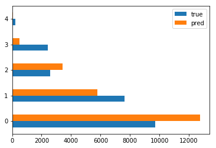

```python
ratios = pd.DataFrame(list(test['attack_category'].value_counts()),columns=['true'])
ratios['true_ratio'] = ratios.true/ratios.true.sum()
ratios['pred'] = results.sum(axis=0)
ratios['pred_ratio'] = ratios.pred/ratios.pred.sum()
ratios['ratio_diff'] = ratios.pred_ratio-ratios.true_ratio
ratios[['true','pred']].plot(kind='barh')
ratios
```

Tulokset ova tmelko samankaltaiset, joskin pientä parannusta on saavutettu. Ottaen huomioon, että tässä vaiheessa ei ole vielä pyritty millään keinoin optimoimaan ennustemallia, kertoo tarkkuuden pienikin lisääntyminen siitä, että datan käsittelyllä on vaikutusta.

Merkittävä huomion arvoinen asia on kuitenkin oikeita vastauksia sisältävän datajoukon koonnin haastavuus. Joissain tapauksissa oikeita vastauksia löytyy jopa helpostikin, mutta näin ei aina ole. Datajoukon rakentaminen siten, että havainnoille löytyy myös oikeat vastauksen ohjatun oppimisen hyödyntämiseksi, on aikaa ja resursseja syövä prosessi. Aina tämän tiedon tuottaminen ei ole edes mahdollista, ainakaan koko datajoukolle. Siksi seuraavaksi keskustellaankin hieman osittain ohjatusta oppimisesta.

### Semi-Supervised Learning

Osittain ohjattu oppiminen on ohjatun oppimisen sateenvarjon alta löytyvä koulutusmetodi, jota käytetään vajaasti oikeita vastauksia sisältävien datajoukkojen kanssa - osasta näytteistä ei ole tietoa niiden oikeista vastauksista tai luokista. Tällöin voidaan esimerkiksi iteroida datajoukkoa siten, että ensin mallinnetaan dataa ohjatusti oikeat tiedot sisältävien havaintojen kanssa, minkä jälkeen mallia käytetään puutteellisten havaintojen luokitteluun tai ennustamiseen. Suurimman luotettavuuden ennusteet liitetään osaksi datajoukkoa, ja iteraatio aloitetaan alusta ja toistetaan, kunnes koulutusjoukko on halutun kokoinen. Näin koottu datajoukko on usein riittävän hyvä käyttöä varten.

### Unsupervised Learning

Joskus oikeat vastaukset puuttuvat tyystin, kuten on laita esimerkiksi kyberturvallisuuden kontekstissa havaintojen lähtökohtaisen luokittelun haastavuuden vuoksi. Tällöin ainut mallinnuksen keino on ohjaamaton oppiminen, jossa menetelmät oppivat datasta merkittäviä ja havaintoja yleisellä tasolla kuvaavia piirteitä nojaten tilastollisiin muuttujiin ja havaintojen ryhmien eroihin.

Usein tässä kohdin puhutaankin ryhmittelystä (*clustering*), jonka alta löytyy monia menetelmiä soveltuen erilaisiin tilanteisiin. Joka tapauksessa kyseessä on havaintoja jollain tapaa ryhmittelevä algoritmi, minkä avulla saadaan luotua edes dataan pohjaavat luokat aiemmin luokittelemattomalle datalle.

Seuraavaksi käydään esimerkinomaisesti läpi ryhmittelymenetelmän käyttä jo tutuksi tulleella datajoukolla.

```python
from sklearn.cluster import KMeans

clustering = KMeans(n_clusters=5).fit(x_train)
y_pred = clustering.predict(x_test)
pd.Series(y_pred).value_counts()
```

```
3    13713
2     5238
0     2086
1     1505
4        2
dtype: int64
```

Ryhmittelymenetelmän tulokset poikkeavat alkuperäisestä kategoriajaosta määrällisesti (ja laadullisestikin, vaikkei sitä vielä ole tarkasteltukaan). Syynä on, että `KMeans`-algoritmi pyrkii löytämään säädetyn määrän riittävän erilaisia ryhmiä perustaen päätöksensä vain datan ominaispiirteisiin eikä niinkään valmiisiin oikeisiin vastauksiin. Ryhmittelyn hyvyyttä onkin mitattava erikseen, tarkastelemalla esimerkiksi ryhmien kokoonpanoa havaintojen osalta.

Katsotaanpa seuraavaksi, kuinka homogeenisiä ja kokonaisia ryhmät ovat, mikä on mahdollista kiitos datajoukon sisältämien oikeiden vastausten. Ryhmä on homogeeninen, kun sen kaikki havainnot ovat yhtä ja samaa luokkaa. Ryhmä on kokonainen, jos jonkin luokan kaikki havainnot ovat siinä. Näiden kahden mitan suhdetta ilmaistaan myös V-mitalla.

```python
from sklearn.metrics import homogeneity_completeness_v_measure
h,c,v = homogeneity_completeness_v_measure(y_test,y_pred)
print(f'Homogeneity score: {h:.4f}')
print(f'Completeness score: {c:.4f}')
print(f'V-measure: {v:.4f}')
```

```
Homogeneity score: 0.2838
Completeness score: 0.3424
V-measure: 0.3104
```

Ryhmittelyn tulokset eivät juuri mairittele. Ryhmät ovat melko sekaluokkaisia ja yksittäiset luokat hajoavat usean ryhmän välille. Vaikka datan uudelleennäytteistyksellä voitaisiinkin pyrkiä vaikuttamaan ryhmittelyn tulokseen, on myös hyödyllistä ymmärtää, ettei jokaista ongelmaa voi lähestyä ryhmittelyn kautta. Jotta tästä on mahdollista saada tietoa etukäteen, on data kyettävä jollain keinoin visualisoimaan. Käyttämässämme datajoukossa on kuitenkin niin paljon piirteitä, ettei sen visualisointi sellaisenaan kahdessa tai kolmessa ulottuvuudessa ole mahdollista.

Tässä kohdin onkin hyvä siis tutustua piirreavaruuden kavennusmenetelmiin (*dimensionality reduction methods*). Eräs tällainen on pääkomponenttianalyysi (*principal component analysis, PCA*). Menetelmä etsii datan piirreavaruudessa sellaiset akselit, joiden suunnassa datan varianssi on suurinta. Nämä akselit toisinsanoen vaikuttavat eniten datan muutoksissa. Näin data saadaan esitettyä huomattavasti pienemmässä piirreavaruudessa, jopa kolmi- tai kaksiulotteisessa sellaisessa.

```python
from sklearn.decomposition import PCA

pca = PCA(n_components=2)
x_train_reduced = pca.fit_transform(x_train)
```

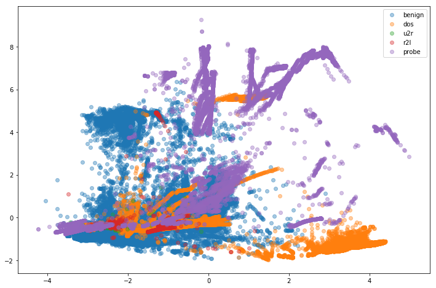

```python
plt.rcParams['figure.figsize'] = 12,8
for category in categories:
    plt.scatter(x_train_reduced[y_train==category, 0],
                x_train_reduced[y_train==category, 1],
                alpha=0.4,
                label=category)
plt.legend()
plt.show()
```

Kuvaajasta voi nähdä, että datajoukon eri luokat ovat melko sekaisin toistensa kanssa. Tästä syystä ryhmittely ei onnistu. Toisaalta tästä ei myöskään ole vaikeata huomata, miten malli ennustaa haitallisia havaintoja normaaleiksi, sillä normaalien havaintojen suuren massan joukossa on paljon haitallisia havaintoja.

Käyttäen tätä visualisoitavaa dataa, lähestytäänpä vielä kertaalleen ryhmittelyä.

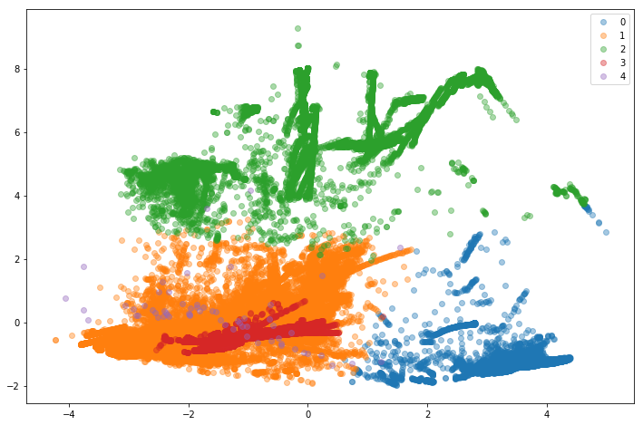

```python
clustering = KMeans(n_clusters=5).fit(x_train)
for category in range(clustering.n_clusters):
    plt.scatter(x_train_reduced[clustering.labels_==category, 0],
                x_train_reduced[clustering.labels_==category, 1],
                alpha=0.4,
                label=category)
plt.legend()
plt.show()
```

Algoritmi löytää ilmeisesti toisistaan eroavat joukot ja myös joitain sisäkkäisiä ryhmiä. Verraten tulosta PCA-kuvaajaan voidaan kuitenkin todeta, että ryhmittelymenetelmä tekee liian raakoja yleistyksiä. Tämä ei yllätä, sillä käytetty `KMeans`-algoritmi toimii parhaiten pallomaisesti jaoteltavan datan kanssa. Tätä meidän datamme ei nähtävästikään ole.

### Advanced Ensembling

Jatketaanpa vielä edellisen esimerkin viitoittamaa tietä, mutta lisäämällä `KMeans`-algoritmin ryhmien määrää.

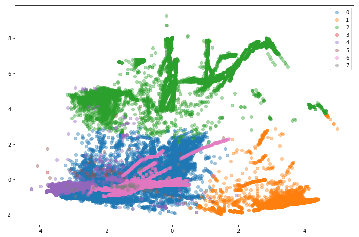

```python
clustering = KMeans(n_clusters=8).fit(x_train)
for category in range(clustering.n_clusters):
    plt.scatter(x_train_reduced[clustering.labels_==category, 0],
                x_train_reduced[clustering.labels_==category, 1],
                alpha=0.4,
                label=category)
plt.legend()
plt.show()
```

Näyttää siltä, että menetelmä kykenee tarkkuutta lisättäessä erottamaan alkuperäiseen dataan nähden ryhmiä jo tarkemmin. Ryhmä nro. 1 näyttää lähes puhtaalta PCA-kuvaajaan verrattuna, mutta esimerkiksi ryhmää no. 2 olisi vielä pystyttävä erottelemaan hienojakoisemmin.

Mikäli näitä ryhmiä pyrittäisiinkin ryhmittelemään sellaisinaan edelleen, voitaisiin kenties saavuttaa tarkempi ryhmittelytulos. Tällöin siirryttäisin yksittäisten mallien käytöstä monen mallin yhteiskäyttöön, jota kutsutaan *ensemble*-mallinnukseksi. Ytimessään esimerkiksi metsämallit ovat *ensemble*-malleja, sillä ne yhdistävät monta yksittäistä puumallia keskimääräisesti tarkan tuloksen saavuttamiseksi. Monta heikompaa mallia tuottaa yhdessä tällöin vahvemman kokonaismallin.